# Bibliographic Studies

Journals Published Articles From Turkey

Serdar Balcı, MD, Pathologist

2018-08-18

# Journals Published Articles From Turkey

If you want to see the code used in the analysis please click the code button on the right upper corner or throughout the page.  
Select from the tabs below.

## Aim

**Aim:**

Here we will look at the Journals in which articles from Turkey are published.

## Data retriveal from PubMed

Articles are downloaded as `xml`.

Journal Names are extracted from xml.

```r
myTerm <- rstudioapi::terminalCreate(show = FALSE)
rstudioapi::terminalSend(
myTerm,
"xtract -input data/Turkey_all.xml -pattern PubmedArticle -element MedlineCitation/PMID PubDate/Year Journal/ISSN ISOAbbreviation > data/TurkeyAll.csv \n"
)
Sys.sleep(1)
repeat {
Sys.sleep(0.1)
if (rstudioapi::terminalBusy(myTerm) == FALSE) {
print("Code Executed")
break
}
}
```

```
[1] "Code Executed"
```

The retrieved information was compiled in a table.

```r
library(readr)

authorkeywords <- read_table2("data/authorkeywords.csv",
col_names = c("frequency", "author key word")) %>%
select('author key word', 'frequency') %>%
head(n = 20)

PathologyTurkeyMeSH <- read_table2("data/PathologyTurkeyMeSH.csv",
col_names = c("frequency", "MeSH term")) %>%
select('MeSH term', 'frequency') %>%
head(n = 20)
```

```r
pander::pander(authorkeywords, justify = "left", caption = "Most common 20 author supplied keywords")
```

[output not shown]

## Properties of Journals

nlmcatalog_result_journals_pmc.xml

nlmcatalog_result_currentlyindexed.xml

[scimagojr2017.csv](https://www.scimagojr.com/journalrank.php?out=xls)

[scimagojr2017-wos.csv](https://www.scimagojr.com/journalrank.php?wos=true&out=xls)

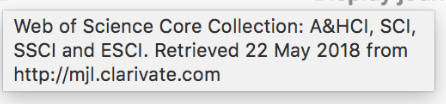

## Old

Articles per journals per country

**Methods:**

```r
# load required packages
library(tidyverse)
library(RISmed)
```

Pathology Journal ISSN List was retrieved from [In Cites Clarivate](https://jcr.incites.thomsonreuters.com/), and Journal Data Filtered as follows: `JCR Year: 2016 Selected Editions: SCIE,SSCI Selected Categories: 'PATHOLOGY' Selected Category Scheme: WoS`

```r
# Get ISSN List from data downloaded from WoS
ISSNList <- JournalHomeGrid <- read_csv("data/JournalHomeGrid.csv",
                                        skip = 1) %>%
    select(ISSN) %>%
    filter(!is.na(ISSN)) %>%
    t() %>%
    paste("OR ", collapse = "") # add OR between ISSN List
ISSNList <- gsub(" OR $","" ,ISSNList) # to remove last OR
```

Data is retrieved from PubMed via RISmed package. PubMed collection from National Library of Medicine (https://www.ncbi.nlm.nih.gov/pubmed/), has the most comprehensive information about peer reviewed articles in medicine. The API (https://dataguide.nlm.nih.gov/), and R packages are available for getting and fetching data from the server.

The search formula for PubMed is generated as “ISSN List AND Country[Affiliation]” like done in [advanced search of PubMed](https://www.ncbi.nlm.nih.gov/pubmed/advanced).

```r
# Generate Search Formula For Pathology Journals AND Countries
searchformulaTR <- paste("'",ISSNList,"'", " AND ", "Turkey[Affiliation]")
searchformulaDE <- paste("'",ISSNList,"'", " AND ", "Germany[Affiliation]")
searchformulaJP <- paste("'",ISSNList,"'", " AND ", "Japan[Affiliation]")
```

Articles from Japan, German and Turkey are retrieved limiting the search with pathology journals, affiliation and last 10 years.

```r
# Search PubMed, Get and Fetch
TurkeyArticles <- EUtilsSummary(searchformulaTR, type = 'esearch', db = 'pubmed', mindate = 2007, maxdate = 2017, retmax = 10000)
fetchTurkey <- EUtilsGet(TurkeyArticles)

GermanyArticles <- EUtilsSummary(searchformulaDE, type = 'esearch', db = 'pubmed', mindate = 2007, maxdate = 2017, retmax = 10000)
fetchGermany <- EUtilsGet(GermanyArticles)

JapanArticles <- EUtilsSummary(searchformulaJP, type = 'esearch', db = 'pubmed', mindate = 2007, maxdate = 2017, retmax = 10000)
fetchJapan <- EUtilsGet(JapanArticles)
```

The retrieved information was compiled in a table.

```r
ISSNTR <- table(ISSN(fetchTurkey)) %>%
    as_tibble() %>%
    rename(Turkey = n, Journal = Var1)
ISSNDE <- table(ISSN(fetchGermany)) %>%
    as_tibble() %>%
    rename(Germany = n, Journal = Var1)
ISSNJP <- table(ISSN(fetchJapan)) %>%
    as_tibble() %>%
    rename(Japan = n, Journal = Var1)
articles_per_journal <- list(
    ISSNTR,
    ISSNDE,
    ISSNJP
) %>%
    reduce(left_join, by = "Journal", .id = "id") %>%
    gather(Country, n, 2:4)
articles_per_journal$Country <- factor(articles_per_journal$Country,
                                       levels =c("Japan", "Germany", "Turkey"))
```

**Result:**

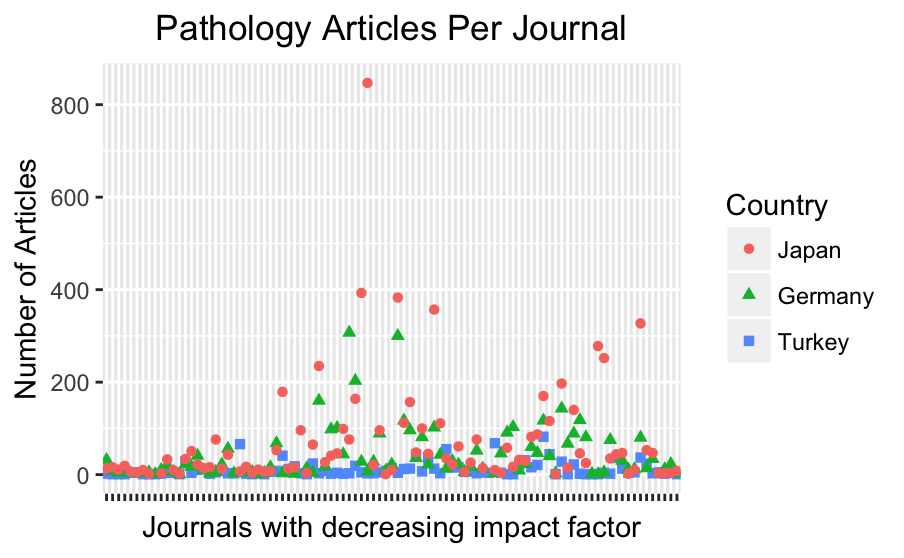

```r
ggplot(data = articles_per_journal, aes(x = Journal, y = n, group = Country,
                                     colour = Country, shape = Country,
                                     levels = Country
)) +
    geom_point() +
    labs(x = "Journals with decreasing impact factor", y = "Number of Articles") +
    ggtitle("Pathology Articles Per Journal") +
    theme(plot.title = element_text(hjust = 0.5),
          axis.text.x=element_blank())
```

**Comment:**

It is seen that one of the journals [ISSN: 1440-1827](https://onlinelibrary.wiley.com/page/journal/14401827/homepage/productinformation.html) has more than 800 articles from Japan. This journal is also from Japan. Here we wonder if there is an editorial preference for articles from their home country.

We sometimes observe this situation if there is a conference in that country, and the conference abstracts are indexed.

This may also be a clue that if a country has a journal listed in indexes, than it is more easy for the researchers in that country to publish their results.

**Future Work:**

Whether this observation is a unique situation, or there is a tendency in the journals to publish article from their country of origin, merits further investigation.

## Feedback

[Serdar Balcı, MD, Pathologist](https://github.com/sbalci) would like to hear your feedback: https://goo.gl/forms/YjGZ5DHgtPlR1RnB3

This document will be continiously updated and the last update was on 2018-08-18.

## Back to Main Menu

[Main Page for Bibliographic Analysis](https://sbalci.github.io/pubmed/BibliographicStudies.html)